# Predictive Modeling for Wildfire Damage Risk

## Model Evaluation Comparison – Single vs Repeated train/test splits

Cross-validation using 5-fold and 10-fold splits was conducted to evaluate model performance across different data partitioning strategies. Both approaches resulted in slightly higher recall but slightly lower precision compared to the single train/test split. However, the differences were minor, suggesting that the model is stable and not highly sensitive to how the data is divided.

```python
logreg_repeated = LogisticRegression(max_iter=3000)
compare_cv_splits(input_X=X,
                  input_y=y,
                  model=LogisticRegression(max_iter=3000),
                  model_name='Logistic Regression',
                  nsplits_list=[5, 10])
```

|  | model | folds | features | avg_acuracy_score | avg_precision_score | avg_recall_sore | avg_f1_score |
| --- | --- | --- | --- | --- | --- | --- | --- |
| 0 | Logistic Regression | 5 | 36 | 0.825 | 0.886 | 0.797 | 0.839 |
| 0 | Logistic Regression | 10 | 36 | 0.825 | 0.884 | 0.798 | 0.839 |

```python
print("Logistic Regression Model Performance on Single Test Set")
classification_evaluation(y_actual=y_test, y_pred=logreg_test_pred)
```

```
Logistic Regression Model Performance on Single Test Set
Accuracy Score : 0.822
Precision Score: 0.894
Recall Score   : 0.785
F1 Score       : 0.836

Confusion Matrix:
```

|  | Predicted: No Damage (0) | Predicted: Destroyed (1) |
| --- | --- | --- |
| Actual: No Damage (0) | 1079 | 158 |
| Actual: Destroyed (1) | 365 | 1333 |

```
Classification Report:
              precision    recall  f1-score   support

           0       0.75      0.87      0.80      1237
           1       0.89      0.79      0.84      1698

    accuracy                           0.82      2935
   macro avg       0.82      0.83      0.82      2935
weighted avg       0.83      0.82      0.82      2935
```

(4). [20] **Predictive Modeling:** Random Forest.

```
- (4.1) On the training set, train a random forest model to predict the target feature, using the descriptive features selected in exercise (1) above.
- (4.2) Can you interpret the random forest model? Discuss any knowledge you can gain in regard of the working of this model.
- (4.3) Print the predicted target feature value for the first 10 training examples. Print the predicted class for the first 10 examples. Print a few classification evaluation measures computed on the full training set (e.g., Accuracy, Confusion matrix, Precision, Recall, F1) and discuss your findings so far.
- (4.4) Evaluate the model using classification evaluation measures on the hold-out (30% examples) test set. Compare these results with the evaluation results obtained when using the training (70%) dataset for evaluation. Also compare these results with a cross-validated model (i.e., a new model trained and evaluated using cross-validation on the full dataset). You can use classic k-fold cross-validation or repeated train/test (70/30) splits. Compare the cross-validation metrics to those obtained on the single train/test split and to the Random Forest out-of-sample error and discuss your findings.
```

# 4. Predictive Modeling: Random Forest

A random forest model is used to capture non-linear relationships and interactions between features. This model is expected to provide improved predictive performance compared to simpler linear models.

## Prepare data

Unlike previous linear and logistic models, Random Forest does not require dropping the first column of one-hot encoded features. Therefore, a full set of encoded features and target variable are generated for training the Random Forest model.

```python
X_rf, _, feature_mapping_rf= encode_features(X_origin, selected_features, drop_first=False)
X_train_rf, X_test_rf, y_train_rf, y_test_rf = train_test_split(X_rf, y, test_size=0.3, random_state=0)
```

## Model Training

```python
rf_model = RandomForestClassifier(random_state=42)
rf_model.fit(X_train_rf, y_train_rf)
rf_train_pred = rf_model.predict(X_train_rf)
rf_test_pred = rf_model.predict(X_test_rf)
```

## Model Importance

Feature importance in a Random Forest model reflects how frequently a feature is used to split data to reduce impurity, rather than whether it directly influences the target variable. To better understand each feature’s effect on severe damage, logistic regression coefficients and interaction plots from earlier sections are used to evaluate the direction and strength of influence.

In summary, top 10 important features include:

**1. Incident Start Year**

- This feature has the highest importance score, indicating that the model often uses it to reduce impurity during decision splits.
- Combined with the negative coefficient observed in the logistic regression model, this suggests that more recent incidents are generally associated with a lower risk of severe damage.

**2. Unknown Categories**

- `Unknown` category in `Exterior Siding`, `Roof Construction`, `Has Vent`, and `Has Vent Screen` all have surprisingly high importance scores.
- Logistic regression shows that unknown values in `Exterior Siding` and `Roof Construction` are associated with lower odds of severe damage. In contrast, unknowns in `Has Vent`, and `Has Vent Screen` are linked to higher risk.

**3. Exterior Siding: Combustible, Wood, Ignition Resistant**

- In addition to the `Unknown` category, materials like `Combustible`, `Wood` and `Ignition Resistant` also rank highly in importance.
- According to logistic regression, `Combustible` and `Ignition Resistant` sidings are related to higher risk, while `Wood` siding appears less risky.

**4. Incident Start Month: November**

- November is one of the most important features based on its score (0.0310) and is associated with a high proportion of severe damage in raw data. However, both logistic and linear regression assign November a negative coefficient (-3.2954) and a very low odds ratio (0.037x), indicating it is not a strong independent risk factor when adjusting for other features.
- This apparent contradiction could be explained by seasonal context. In California, November follows an extended dry period, and Santa Ana Winds are common during this time. These conditions make November a critical time for fires to spread rapidly, especially when other risk factors are present, such as older homes or poor materials.
- In summary, although November itself may not increase risk directly, it often coincides with high-risk events. This makes it valuable for splitting decisions in the Random Forest model.

**5. Roof construction: Fire Resistant**

- `Fire Resistant` roofs appear among the most important categories.
- Interestingly, logistic regression shows that `Combustible` and `Wood` roofs are more strongly associated with higher risk than `Fire Resistant` roofs. This suggests that `Fire Resistant` types often appear alongside other risk features, which increases their usefulness for tree-based splits even if their individual contribution is moderate.

```python
feature_importance_rf = gen_model_coefficients(input_coef=rf_model.feature_importances_,
                                               input_features=X_train_rf.columns,
                                               feature_mapping_df=feature_mapping_rf,
                                               coef_name='importance')
feature_importance_rf
```

|  | original_feature | feature | importance |
| --- | --- | --- | --- |
| 0 | structure_type | structure_type_Single Family Residence Multi S... | 0.0194 |
| 1 | structure_type | structure_type_Utility Misc Structure | 0.0152 |
| 2 | structure_type | structure_type_Single Family Residence Single ... | 0.0140 |
| 3 | structure_type | structure_type_Mobile Home Double/Triple Wide | 0.0084 |
| 4 | structure_type | structure_type_Commercial Building | 0.0079 |
| 5 | structure_type | structure_type_Multi Family Residence | 0.0048 |
| 6 | structure_type | structure_type_Mobile Home Single Wide | 0.0046 |
| 7 | structure_type | structure_type_Motor Home | 0.0044 |
| 8 | roof_construction | roof_construction_Unknown | 0.0559 |
| 9 | roof_construction | roof_construction_Fire Resistant | 0.0276 |
| 10 | roof_construction | roof_construction_Asphalt | 0.0249 |
| 11 | roof_construction | roof_construction_Tile | 0.0178 |
| 12 | roof_construction | roof_construction_Metal | 0.0134 |
| 13 | roof_construction | roof_construction_Other | 0.0064 |
| 14 | roof_construction | roof_construction_Wood | 0.0035 |
| 15 | roof_construction | roof_construction_Combustible | 0.0011 |
| 16 | incident_start_year | incident_start_year | 0.2641 |
| 17 | incident_start_month | incident_start_month_11 | 0.0310 |
| 18 | incident_start_month | incident_start_month_1 | 0.0253 |
| 19 | incident_start_month | incident_start_month_8 | 0.0217 |
| 20 | incident_start_month | incident_start_month_9 | 0.0162 |
| 21 | incident_start_month | incident_start_month_7 | 0.0115 |
| 22 | incident_start_month | incident_start_month_10 | 0.0094 |
| 23 | incident_start_month | incident_start_month_12 | 0.0093 |
| 24 | incident_start_month | incident_start_month_6 | 0.0031 |
| 25 | incident_start_month | incident_start_month_2 | 0.0003 |
| 26 | incident_start_month | incident_start_month_5 | 0.0003 |
| 27 | has_vent_screen | has_vent_screen_Unknown | 0.0480 |
| 28 | has_vent_screen | has_vent_screen_Unscreened | 0.0222 |
| 29 | has_vent_screen | has_vent_screen_Screened | 0.0129 |
| 30 | has_vent | has_vent_Unknown | 0.0327 |
| 31 | has_vent | has_vent_No Vents | 0.0189 |
| 32 | has_vent | has_vent_Has Vents | 0.0126 |
| 33 | exterior_siding | exterior_siding_Combustible | 0.0624 |
| 34 | exterior_siding | exterior_siding_Unknown | 0.0496 |
| 35 | exterior_siding | exterior_siding_Wood | 0.0366 |
| 36 | exterior_siding | exterior_siding_Ignition Resistant | 0.0317 |
| 37 | exterior_siding | exterior_siding_Stucco Brick Cement | 0.0272 |
| 38 | exterior_siding | exterior_siding_Fire Resistant | 0.0084 |
| 39 | exterior_siding | exterior_siding_Metal | 0.0067 |
| 40 | exterior_siding | exterior_siding_Vinyl | 0.0044 |
| 41 | exterior_siding | exterior_siding_Other | 0.0040 |

```python
feature_importance_rf.sort_values('importance', ascending=False).head(10)
```

|  | original_feature | feature | importance |
| --- | --- | --- | --- |
| 16 | incident_start_year | incident_start_year | 0.2641 |
| 33 | exterior_siding | exterior_siding_Combustible | 0.0624 |
| 8 | roof_construction | roof_construction_Unknown | 0.0559 |
| 34 | exterior_siding | exterior_siding_Unknown | 0.0496 |
| 27 | has_vent_screen | has_vent_screen_Unknown | 0.0480 |
| 35 | exterior_siding | exterior_siding_Wood | 0.0366 |
| 30 | has_vent | has_vent_Unknown | 0.0327 |
| 36 | exterior_siding | exterior_siding_Ignition Resistant | 0.0317 |
| 17 | incident_start_month | incident_start_month_11 | 0.0310 |
| 9 | roof_construction | roof_construction_Fire Resistant | 0.0276 |

```python
feature_importance_rf.describe()
```

|  | importance |
| --- | --- |
| count | 42.000000 |
| mean | 0.023805 |
| std | 0.040962 |
| min | 0.000300 |
| 25% | 0.006475 |
| 50% | 0.013700 |
| 75% | 0.026725 |
| max | 0.264100 |

To better understand the classification process, the first decision tree from the random forest is visualized below. In this tree, `exterior_siding_Wood` appears as the root node, indicating that it was considered the most informative feature for splitting the data within that particular subset. At the second level, features such as `incident_start_year` and `roof_construction_Asphalt` are used to further refine the decision boundaries.

Interestingly, this structure differs slightly from the overall feature importance rankings, where `incident_start_year` holds the highest importance score. This discrepancy is expected, as feature importance in a random forest is calculated based on the aggregate contribution of each feature across all trees in the ensemble. In contrast, the structure of an individual tree is determined by the training data subset and the feature sampling at each split.

This highlights a core principle of ensemble learning: while individual trees may vary in their splitting criteria and structure due to the randomness introduced during training, the collective behavior of all trees leads to a more stable and accurate model. Therefore, a single tree offers insight into one possible decision path, whereas the overall feature importance reflects broader trends learned by the model.

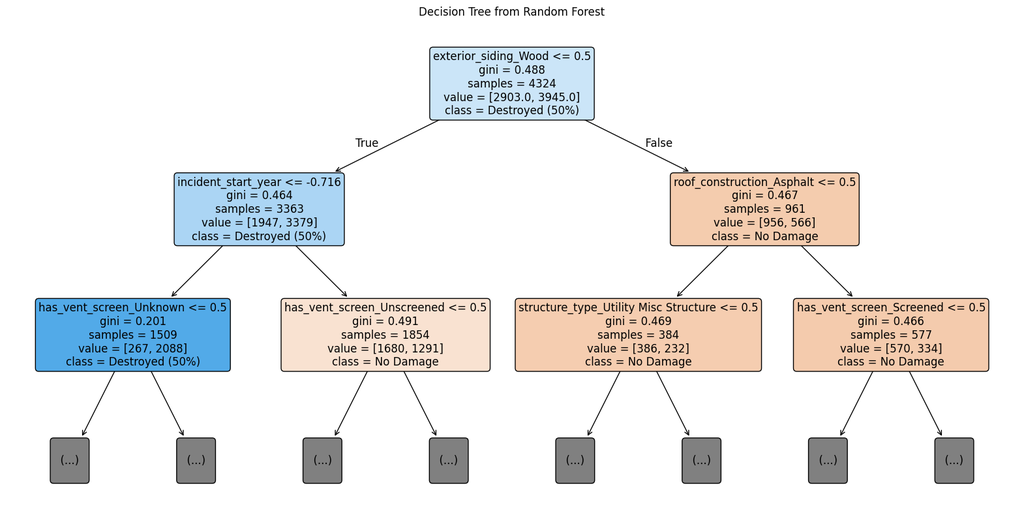

```python
# Pick the first tree of the trees in the forest
tree = rf_model.estimators_[0]

# Plot the tree
plt.figure(figsize=(20, 10))  # you can adjust the size if needed
plot_tree(tree,
          filled=True,
          feature_names=X_rf.columns,
          class_names=["No Damage", "Destroyed (50%)"],
          rounded=True,
          max_depth=2,
          fontsize=12)
plt.title("Decision Tree from Random Forest")
plt.show()
```

## Model Evaluation - Training Set

- The model performs very well on the training set, with accuracy, precision, recall, and F1-score all exceeding 0.88.

```python
rf_train_result = gen_prediction_comparison(y_actual=y_train_rf, y_pred=rf_train_pred, set_type='train')
rf_train_result[:10]
```

|  | y_train_actual | y_train_pred |
| --- | --- | --- |
| 0 | 1 | 1 |
| 1 | 1 | 1 |
| 2 | 0 | 0 |
| 3 | 0 | 0 |
| 4 | 0 | 0 |
| 5 | 0 | 0 |
| 6 | 0 | 0 |
| 7 | 1 | 1 |
| 8 | 1 | 1 |
| 9 | 1 | 1 |

```python
print("Random Forest Model Performance on Tranining Set")
classification_evaluation(y_actual=rf_train_result['y_train_actual'], y_pred=rf_train_result['y_train_pred'])
```

```
Random Forest Model Performance on Tranining Set
Accuracy Score : 0.887
Precision Score: 0.908
Recall Score   : 0.891
F1 Score       : 0.9

Confusion Matrix:
```

|  | Predicted: No Damage (0) | Predicted: Destroyed (1) |
| --- | --- | --- |
| Actual: No Damage (0) | 2596 | 351 |
| Actual: Destroyed (1) | 425 | 3476 |

```
Classification Report:
              precision    recall  f1-score   support

           0       0.86      0.88      0.87      2947
           1       0.91      0.89      0.90      3901

    accuracy                           0.89      6848
   macro avg       0.88      0.89      0.88      6848
weighted avg       0.89      0.89      0.89      6848
```

## Model Evaluation Comparison – Training vs Test Set

Overall, the model’s test performance is about 4% lower than on the training set. However, accuracy, precision, recall, and F1-score remain close to 0.85, suggesting that the model generalizes well to unseen data. This indicates stable classification performance with no signs of overfitting.

```python
print("Random Forest Model Performance on Tranining Set")
rf_train_pred_probs = rf_model.predict_proba(X_train_rf)[:, 1]
print('AUC score:', round(roc_auc_score(y_train_rf, rf_train_pred_probs), 2))
classification_evaluation(y_actual=y_train_rf, y_pred=rf_train_pred)

print("Random Forest Model Performance on Test Set")
rf_test_pred_probs = rf_model.predict_proba(X_test_rf)[:, 1]
print('AUC score:', round(roc_auc_score(y_test_rf, rf_test_pred_probs), 2))
classification_evaluation(y_actual=y_test_rf, y_pred=rf_test_pred)
```

```
Random Forest Model Performance on Tranining Set
AUC score: 0.96
Accuracy Score : 0.887
Precision Score: 0.908
Recall Score   : 0.891
F1 Score       : 0.9

Confusion Matrix:
```

|  | Predicted: No Damage (0) | Predicted: Destroyed (1) |
| --- | --- | --- |
| Actual: No Damage (0) | 2596 | 351 |
| Actual: Destroyed (1) | 425 | 3476 |

```
Classification Report:
              precision    recall  f1-score   support

           0       0.86      0.88      0.87      2947
           1       0.91      0.89      0.90      3901

    accuracy                           0.89      6848
   macro avg       0.88      0.89      0.88      6848
weighted avg       0.89      0.89      0.89      6848

Random Forest Model Performance on Test Set
AUC score: 0.92
Accuracy Score : 0.836
Precision Score: 0.861
Recall Score   : 0.853
F1 Score       : 0.857

Confusion Matrix:
```

|  | Predicted: No Damage (0) | Predicted: Destroyed (1) |
| --- | --- | --- |
| Actual: No Damage (0) | 1016 | 233 |
| Actual: Destroyed (1) | 247 | 1439 |

```
Classification Report:
              precision    recall  f1-score   support

           0       0.80      0.81      0.81      1249
           1       0.86      0.85      0.86      1686

    accuracy                           0.84      2935
   macro avg       0.83      0.83      0.83      2935
weighted avg       0.84      0.84      0.84      2935
```

## Model Evaluation Comparison – Single vs Repeated train/test splits

```python
compare_cv_splits(input_X=X_rf,
                  input_y=y,
                  model=rf_model,
                  model_name='Random Forest',
                  nsplits_list=[5, 10])
```

|  | model | folds | features | avg_acuracy_score | avg_precision_score | avg_recall_sore | avg_f1_score |
| --- | --- | --- | --- | --- | --- | --- | --- |
| 0 | Random Forest | 5 | 42 | 0.847 | 0.871 | 0.859 | 0.865 |
| 0 | Random Forest | 10 | 42 | 0.846 | 0.870 | 0.858 | 0.864 |

```python
print("Random Forest Model Performance on Test Set")
classification_evaluation(y_actual=y_test_rf, y_pred=rf_test_pred)
```

```
Random Forest Model Performance on Test Set
Accuracy Score : 0.836
Precision Score: 0.861
Recall Score   : 0.853
F1 Score       : 0.857

Confusion Matrix:
```

|  | Predicted: No Damage (0) | Predicted: Destroyed (1) |
| --- | --- | --- |
| Actual: No Damage (0) | 1016 | 233 |
| Actual: Destroyed (1) | 247 | 1439 |

```
Classification Report:
              precision    recall  f1-score   support

           0       0.80      0.81      0.81      1249
           1       0.86      0.85      0.86      1686

    accuracy                           0.84      2935
   macro avg       0.83      0.83      0.83      2935
weighted avg       0.84      0.84      0.84      2935
```

# 5. Improving Predictive Models

This section explores strategies to improve model performance, including feature engineering, feature selection, and evaluation against baseline models. The goal is to identify the most effective approach for predicting wildfire damage risk.

## Models Comparison

- Since the dataset has relatively balanced classes (with a destruction rate of around 57%), simply predicting the majority class (Destroyed (>50%)) would only yield about 57% accuracy. Although this naive strategy achieves a perfect recall, it comes at the cost of a large number of false positives. Such false alarms can lead to inefficient allocation of emergency resources, as this strategy would incorrectly predict many areas to be at high risk, thereby diverting attention away from truly critical zones. As a result, this approach is not sufficient for real-world disaster response and highlights the need for a more balanced and accurate prediction model.
- Among the models, the logistic regression model achieves the highest precision score but the lowest recall. This conservative prediction tendency may not be ideal in this context—since the goal is to predict wildfire damage severity, underestimating the risk could lead to serious consequences. In comparison, the **Random Forest model** demonstrates the best overall performance. Although its precision (0.861) is slightly lower than that of logistic regression (0.894), it achieves the highest scores in all other metrics, making it the most suitable model in this case.
- As a result, the **Random Forest model** achieves the best overall performance and can be considered a good baseline for future model improvements.

```python
# The majority is Destroyed(1)
print("Destruction rate:", round(y.mean(), 2))
print("Destruction rate in test set:", round(y_test.mean(), 2))
```

```
Destruction rate: 0.57
Destruction rate in test set: 0.58
```

```python
print("Linear Regression Model Performance on Test Set:")
classification_evaluation(y_actual=linreg_test_result['y_test_actual'], y_pred=linreg_test_result['y_test_pred_class'])

print("Logistic Regression Model Performance on Test Set:")
print('AUC score:', round(roc_auc_score(y_test, logreg_test_pred_probs), 2))
classification_evaluation(y_actual=y_test, y_pred=logreg_test_pred)

print("Random Forest Model Performance on Test Set:")
print('AUC score:', round(roc_auc_score(y_test_rf, rf_test_pred_probs), 2))
classification_evaluation(y_actual=y_test_rf, y_pred=rf_test_pred)

simple_model_results = np.array([1 for _ in range(len(y_test))])
print("Simple model that always predicts the destroyed class(1):")
classification_evaluation(y_actual=y_test, y_pred=simple_model_results)
```

```
Linear Regression Model Performance on Test Set:
Accuracy Score : 0.819
Precision Score: 0.855
Recall Score   : 0.826
F1 Score       : 0.84

Confusion Matrix:
```

|  | Predicted: No Damage (0) | Predicted: Destroyed (1) |
| --- | --- | --- |
| Actual: No Damage (0) | 1012 | 237 |
| Actual: Destroyed (1) | 294 | 1392 |

```
Classification Report:
              precision    recall  f1-score   support

           0       0.77      0.81      0.79      1249
           1       0.85      0.83      0.84      1686

    accuracy                           0.82      2935
   macro avg       0.81      0.82      0.82      2935
weighted avg       0.82      0.82      0.82      2935

Logistic Regression Model Performance on Test Set:
AUC score: 0.91
Accuracy Score : 0.822
Precision Score: 0.894
Recall Score   : 0.785
F1 Score       : 0.836

Confusion Matrix:
```

|  | Predicted: No Damage (0) | Predicted: Destroyed (1) |
| --- | --- | --- |
| Actual: No Damage (0) | 1079 | 158 |
| Actual: Destroyed (1) | 365 | 1333 |

```
Classification Report:
              precision    recall  f1-score   support

           0       0.75      0.87      0.80      1237
           1       0.89      0.79      0.84      1698

    accuracy                           0.82      2935
   macro avg       0.82      0.83      0.82      2935
weighted avg       0.83      0.82      0.82      2935

Random Forest Model Performance on Test Set:
AUC score: 0.92
Accuracy Score : 0.836
Precision Score: 0.861
Recall Score   : 0.853
F1 Score       : 0.857

Confusion Matrix:
```

|  | Predicted: No Damage (0) | Predicted: Destroyed (1) |
| --- | --- | --- |
| Actual: No Damage (0) | 1016 | 233 |
| Actual: Destroyed (1) | 247 | 1439 |

```
Classification Report:
              precision    recall  f1-score   support

           0       0.80      0.81      0.81      1249
           1       0.86      0.85      0.86      1686

    accuracy                           0.84      2935
   macro avg       0.83      0.83      0.83      2935
weighted avg       0.84      0.84      0.84      2935

Simple model that always predicts the destroyed class(1):
Accuracy Score : 0.579
Precision Score: 0.579
Recall Score   : 1.0
F1 Score       : 0.733

Confusion Matrix:
```

|  | Predicted: No Damage (0) | Predicted: Destroyed (1) |
| --- | --- | --- |
| Actual: No Damage (0) | 0 | 1237 |
| Actual: Destroyed (1) | 0 | 1698 |

```
Classification Report:
              precision    recall  f1-score   support

           0       1.00      0.00      0.00      1237
           1       0.58      1.00      0.73      1698

    accuracy                           0.58      2935
   macro avg       0.79      0.50      0.37      2935
weighted avg       0.76      0.58      0.42      2935
```

## Summarize current status

This analysis aims to predict `damage` severity (Destroyed (>50%) vs. No Damage) using seven selected features and three models: Linear Regression, Logistic Regression, and Random Forest. Among them, the Random Forest model demonstrated the best performance and will serve as the baseline for further development.

Although Linear Regression was adapted for binary classification via a 0.5 threshold, its coefficients are less interpretable in this context. Therefore, the following summary of feature–target relationships draws on Logistic Regression coefficients and Random Forest feature importance to provide a more meaningful interpretation.

**1. Structure Type**

- `Motor Home` and `Mobile Home (Single/Double/Triple Wide)` are independently associated with a high risk of severe damage. However, they do not frequently co-occur with other high-risk features, which results in lower importance scores in the Random Forest model.

**2. Roof Construction**

**3. Incident Start Year**

- This feature has an odds ratio of 0.21 and the highest importance score in the Random Forest model. This suggests that more recent incidents tend to have a substantially lower risk of severe damage, but the feature is still frequently used for splitting due to its interactions with other predictors.

**4. Incident Start Month**

- While November is considered a high-risk wildfire month due to environmental factors like dry vegetation and strong winds, the logistic regression model suggests that increased damage severity during this month is likely due to co-occurring structural vulnerabilities (e.g., older buildings, flammable materials).
- In contrast, the Random Forest model assigns high importance to November, likely due to its correlation with overall damage patterns rather than direct causation. This emphasizes the need to interpret feature importance in context, considering both model behavior and domain knowledge.

**5. Has Vent Screen**  
**6. Has Vent**

- Properties with `Unknown` vent or vent screen types are linked to the highest risk and are ranked as important features in the Random Forest model.
- Overall risk hierarchy: `Unknown` > `Screened` or `Has Vents` > `Unscreened` or `No Vents`.

**7. Exterior Siding**

## Improve the model

To enhance the stability and accuracy of the Random Forest model, various techniques are applied to the features below.

### Method 1: Add new features

- Previously, only categorical features with cardinality less than 10 are considered. In this section, the relationship between high-cardinality features and the target variable will be explored.
- Analysis reveals that features such as `city`, `zip_code`, `cal_fire_unit`, `county`, and `incident_start_date` exhibit strong or very strong associations with damage severity. However, directly encoding high-cardinality features can cause dimensionality explosion and increase the risk of overfitting.
- To address this, different strategies are applied based on each feature's characteristics:
  - `city`, `zip_code`, `cal_fire_unit`, `county`:
    - Use a 50% damage rate threshold to identify high-risk categories.
    - Convert these into binary indicator features: `is_high_risk_city`, `is_high_risk_zip_code`, `is_high_risk_cal_fire_unit`, `is_high_risk_county`
  - `incident_start_date`:
    - Rather than using full date strings, a more fine-grained time-based feature,`incident_start_week`, is added in addition to the existing `incident_start_month` and `incident_start_year` features represent the date more precisely.
- Based on these strategies, two feature engineering approaches are compared:
  1. **v2**: Allows moderate-cardinality features and only transforms features with cardinality > 50 into high-risk indicators.
     - Added features include: `incident_start_week`, `is_high_risk_city`, `county`, `cal_fire_unit`, and `is_high_risk_zip_code`
  2. **v3**: Converts all new features with cardinality > 10 into binary high-risk indicators.
     - Added features include: `is_high_risk_incident_start_week`, `is_high_risk_city`, `is_high_risk_zip_code`, `is_high_risk_cal_fire_unit`, and `is_high_risk_county`.
- According to cross-validation results, both v2 and v3 outperform the baseline model in terms of accuracy, precision, recall, and F1 score. Among them, **v2** achieves the highest performance across all metrics, with improvements of 2%–4% over the baseline. This suggests that incorporating high-cardinality features using a moderate transformation strategy (as in v2) can effectively enhance the model’s predictive ability without introducing excessive complexity.

```python
# city, zip_code, cal_fire_unit, county, and incident_start_date all exhibit strong to very strong associations with damage severity
categorical_features = X_train_origin.select_dtypes(['category', 'datetime']).columns
target_categorical_features = []
for col in X_train_origin.select_dtypes(['category', 'datetime']).columns:
    if X_train_origin[col].nunique() > 10:
        target_categorical_features.append(col)

for col in target_categorical_features:
    analyze_categorical_vs_damage(train_df, col)

summarize_columns(X_train_origin[target_categorical_features])
```

```
Feature: street_type
Weak association with damage severity (Cramér's V:0.129)
Feature: city
👑 Very strong association with Damage (Cramér's V:0.627)
Feature: zip_code
👑 Very strong association with Damage (Cramér's V:0.627)
Feature: cal_fire_unit
🌟 Strong association with Damage (Cramér's V:0.376)
Feature: county
🌟 Strong association with Damage (Cramér's V:0.430)
Feature: incident_start_date
👑 Very strong association with Damage (Cramér's V:0.572)
```

|  | col_name | unique_values | dtype | example | missing% |
| --- | --- | --- | --- | --- | --- |
| 0 | street_type | 13 | category | Road | 0.0 |
| 1 | city | 87 | category | Unincorporated | 0.0 |
| 2 | zip_code | 274 | category | 91342 | 0.0 |
| 3 | cal_fire_unit | 26 | category | LAC | 0.0 |
| 4 | county | 47 | category | Los Angeles | 0.0 |
| 5 | incident_start_date | 143 | datetime64[ns] | 2017-12-05 00:00:00 | 0.0 |

```
Feature: incident_start_week
🌟 Strong association with Damage (Cramér's V:0.462)
```

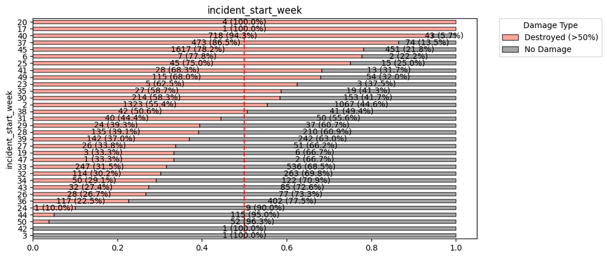

```
Feature: is_high_risk_city
🌟 Strong association with Damage (Cramér's V:0.499)
```

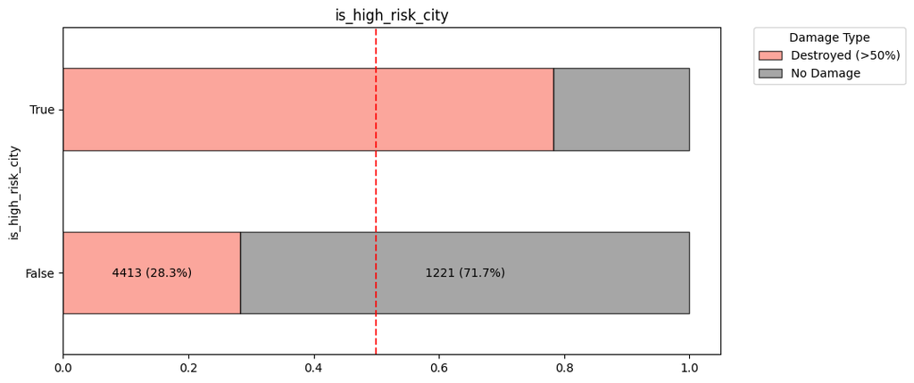

```
Feature: is_high_risk_zip_code
👑 Very strong association with Damage (Cramér's V:0.518)
```

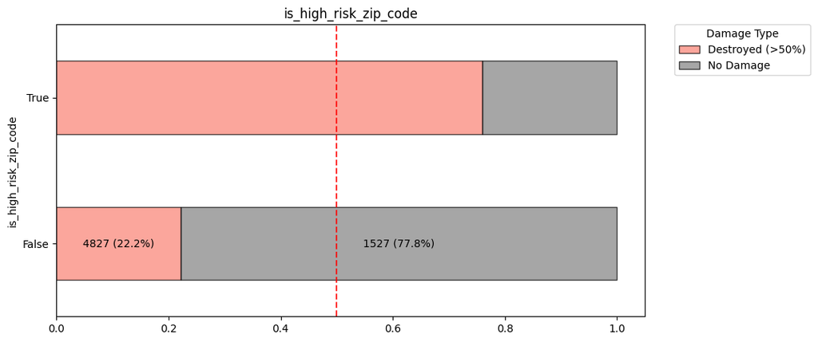

```
Feature: is_high_risk_cal_fire_unit
🌟 Strong association with Damage (Cramér's V:0.314)
```

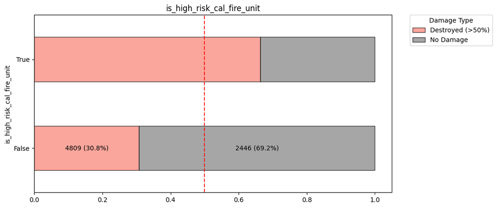

```
Feature: is_high_risk_county
🌟 Strong association with Damage (Cramér's V:0.352)
```

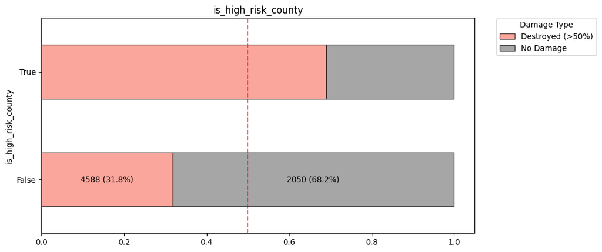

```
Feature: is_high_risk_incident_start_week
🌟 Strong association with Damage (Cramér's V:0.385)
```

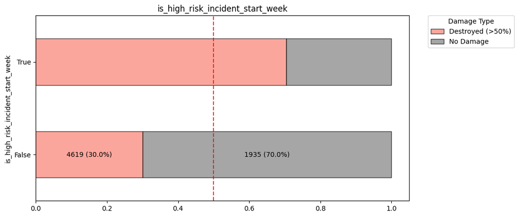

```python
# Extract the incident_start_week from incident_start_date
df['incident_start_week'] = (pd.to_datetime(df['incident_start_date']).dt.isocalendar().week).astype('category')

# New features are added directly to the original df DataFrame
strong_association_features = ['city', 'zip_code', 'cal_fire_unit', 'county', 'incident_start_week']
new_created_features = ['incident_start_week']
for col in strong_association_features:
    df = label_high_risk_categories(df, col)
    new_created_features.append(f'is_high_risk_{col}')

for col in new_created_features:
    analyze_categorical_feature(df, col)
```

```python
# Get the X_origin_v2 from df to obtain added features
X_origin_v2 = df.drop(columns=['OBJECTID', 'damage'])

# selected_features_v2
selected_features_v2 = selected_features.copy()
selected_features_v2 += ['incident_start_week', 'is_high_risk_city', 'county', 'cal_fire_unit', 'is_high_risk_zip_code']

# selected_features_v3
selected_features_v3 = selected_features.copy()
selected_features_v3 += ['is_high_risk_incident_start_week', 'is_high_risk_city', 'is_high_risk_zip_code', 'is_high_risk_cal_fire_unit', 'is_high_risk_county']

# Encode the features for selected_features_v2
X_v2, dropped_cols_v2, feature_mapping_v2 = encode_features(X_origin_v2, selected_features_v2, drop_first=False)

# Encode the features for selected_features_v3
X_v3, dropped_cols_v2, feature_mapping_v2 = encode_features(X_origin_v2, selected_features_v3, drop_first=False)

# Compare the performance by cross-validation results
feature_versions = {}
feature_versions['v2'] = X_v2
feature_versions['v3'] = X_v3
compare_rf_cv(feature_versions)
```

|  | model | folds | features | avg_acuracy_score | avg_precision_score | avg_recall_sore | avg_f1_score |
| --- | --- | --- | --- | --- | --- | --- | --- |
| 0 | RF (baseline) | 5 | 36 | 0.847 | 0.872 | 0.858 | 0.865 |
| 0 | RF (v2) | 5 | 151 | 0.878 | 0.893 | 0.894 | 0.893 |
| 0 | RF (v3) | 5 | 52 | 0.868 | 0.886 | 0.882 | 0.884 |

### Method 2: Remove high correlated features

- After analyzing the correlations among categorical features, several features with high collinearity were removed. The selection process considered multiple factors, including cardinality, uncertainty ratio, and feature influence scope. As a result, `selected_features_v4` was created by duplicating `selected_features_v2` and excluding `has_vent_screen`, `incident_start_week`, `is_high_risk_city`, and `county`.
- According to cross-validation results, v4 demonstrates negligible performance differences compared to v2, while using less than half the number of features (67 vs. 151). This makes v4 a strong candidate for lightweight or real-time applications where model efficiency is critical.

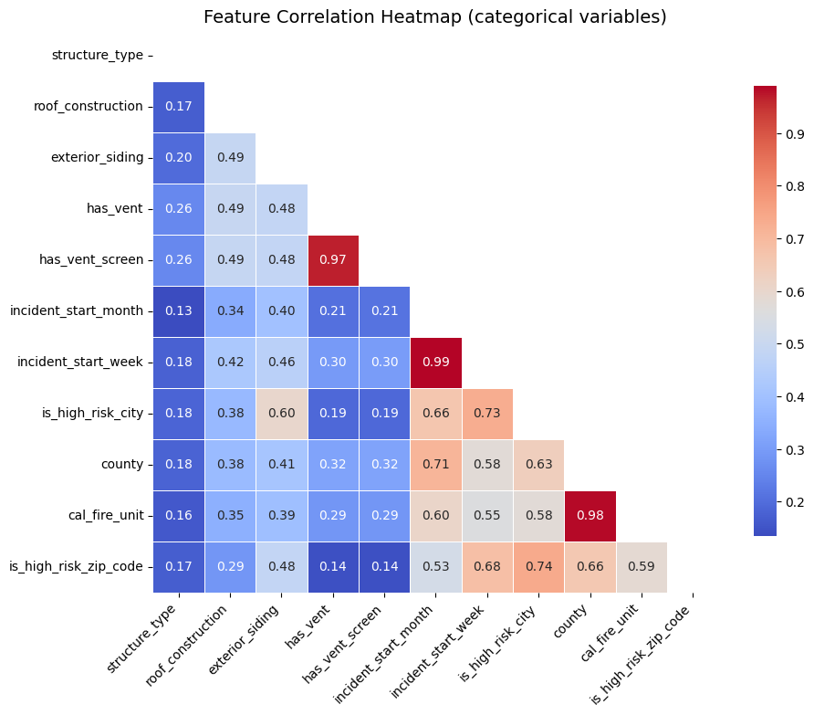

```python
target_cols = X_origin_v2[selected_features_v2].select_dtypes(['category', 'bool']).columns
plot_feature_correlation_heatmap(X_origin_v2, target_cols, 'categorical')
```

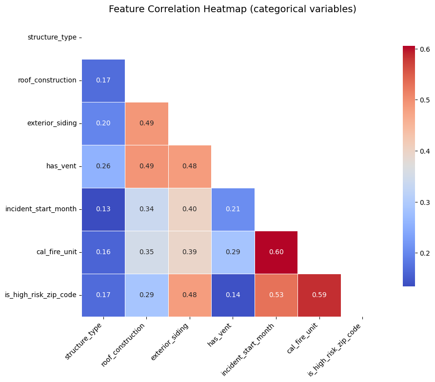

```python
selected_features_v4 = selected_features_v2.copy()
selected_features_v4.remove('has_vent_screen')  # Redundant: has_vent_screen is a finer-grained detail of has_vent -> keep has_vent
selected_features_v4.remove('incident_start_week')  # High cardinality and overlaps with incident_start_month -> keep month
selected_features_v4.remove('is_high_risk_city')  # Redundant with is_high_risk_zip_code while ZIP is more granular and informative
selected_features_v4.remove('county')  # Higher cardinality and more missing values than cal_fire_unit -> keep cal_fire_unit

target_cols = X_origin_v2[selected_features_v4].select_dtypes(['category', 'bool']).columns
plot_feature_correlation_heatmap(X_origin_v2, target_cols)
```

```python
# Encode the features
X_v4, dropped_cols_v4, feature_mapping_v4 = encode_features(X_origin_v2, selected_features_v4, drop_first=False)

feature_versions = {}
feature_versions['v2'] = X_v2
feature_versions['v4'] = X_v4

# Compare the performance by cross-validation results
compare_rf_cv(feature_versions)
```

|  | model | folds | features | avg_acuracy_score | avg_precision_score | avg_recall_sore | avg_f1_score |
| --- | --- | --- | --- | --- | --- | --- | --- |
| 0 | RF (baseline) | 5 | 36 | 0.847 | 0.872 | 0.858 | 0.865 |
| 0 | RF (v2) | 5 | 151 | 0.878 | 0.893 | 0.894 | 0.893 |
| 0 | RF (v4) | 5 | 67 | 0.875 | 0.888 | 0.894 | 0.891 |